# InSilicoDb Analysis

Alyssa Frazee

August 19, 2014

## analysis of publicly-available datasets with Cuffdiff, Ballgown, and EBSeq

```r
library(devtools)
install_github('alyssafrazee/usefulstuff')
library(ballgown)
library(reshape2)
library(limma)
library(usefulstuff)
library(EBSeq)
```

### dataset 1: cancer

The first study we examined compares expression between lung adenocarcinoma (n=12) and normal (n=12) cells. Study information is [available here](http://www.ncbi.nlm.nih.gov/geo/query/acc.cgi?acc=GSE37764). (GEO/NCBI accession number GSE37764).

First we present the transcript-level differential expression results from Cuffdiff, version 2.2.1. (See other scripts in this folder for details on how Cuffdiff was run).

```r
transcripts = read.table('cancer/isoform_exp.diff', header=TRUE)
rdata = read.table('cancer/isoforms.read_group_tracking', header=TRUE)
fpkmtable = dcast(rdata, formula=tracking_id~replicate+condition, value.var='FPKM')
hiexpr = which(rowMeans(fpkmtable[,-1]) > 1)
length(hiexpr)
```

```
## [1] 19748
```

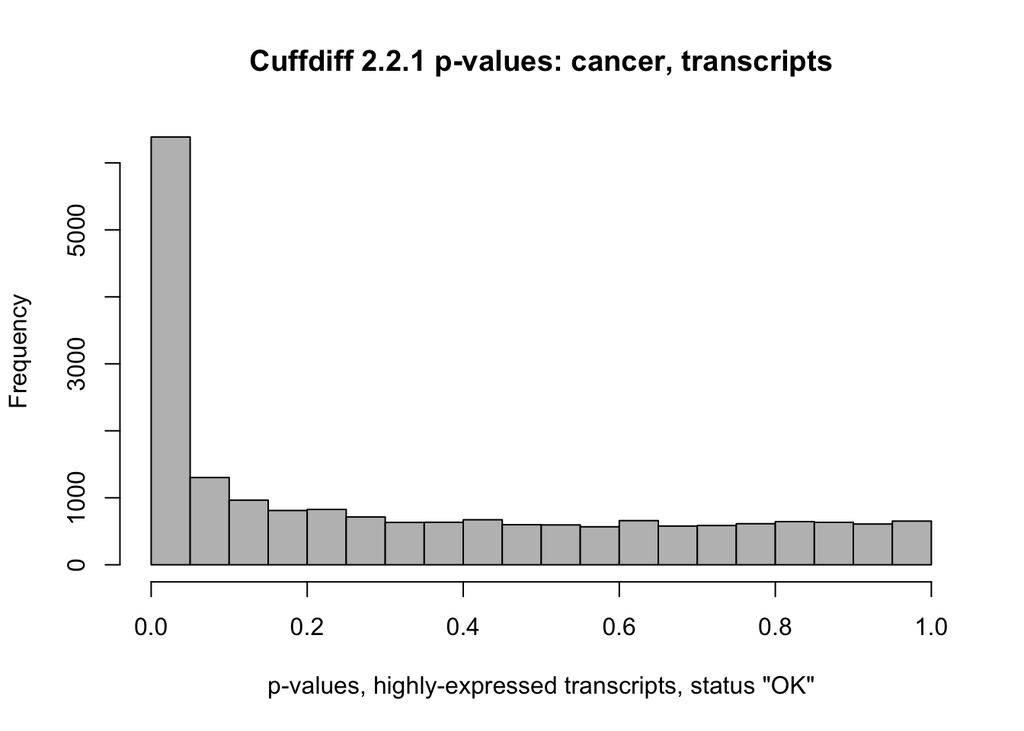

```r
hiID = fpkmtable$tracking_id[hiexpr]
hitranscripts = subset(transcripts, test_id %in% hiID)
hist(hitranscripts$p_value[hitranscripts$status == "OK"], xlab='p-values, highly-expressed transcripts, status "OK"', main='Cuffdiff 2.2.1 p-values: cancer, transcripts', col='gray')
```

This is a *huge* improvement over Cuffdiff 2.0.2! (Results from Cuffdiff 2.0.2 are available in InSilicoDb). The gene-level p-values are below:

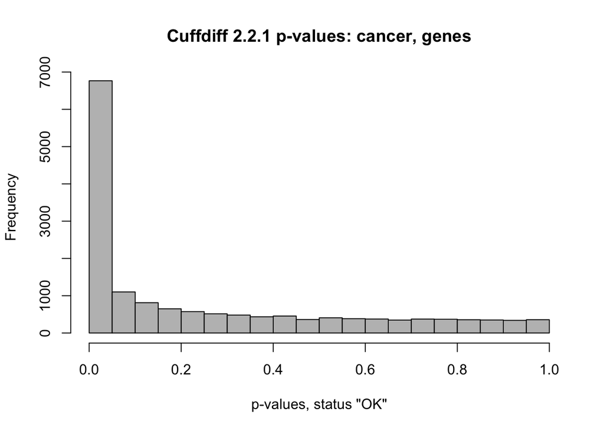

```r
genes = read.table('cancer/gene_exp.diff', header=TRUE)
hist(genes$p_value[genes$status=="OK"], main='Cuffdiff 2.2.1 p-values: cancer, genes', xlab='p-values, status "OK"', col='gray')
```

Next we calculate Ballgown p-values for comparison:

```r
bgtable = fpkmtable[,-1]
rownames(bgtable) = fpkmtable[,1]
system.time(bgresults <- stattest(gowntable=bgtable,
    pData=data.frame(group=as.numeric(grepl('tumor', names(bgtable)))),
    feature='transcript', covariate='group'))
```

```
##    user  system elapsed
##   0.695   0.081   0.780
```

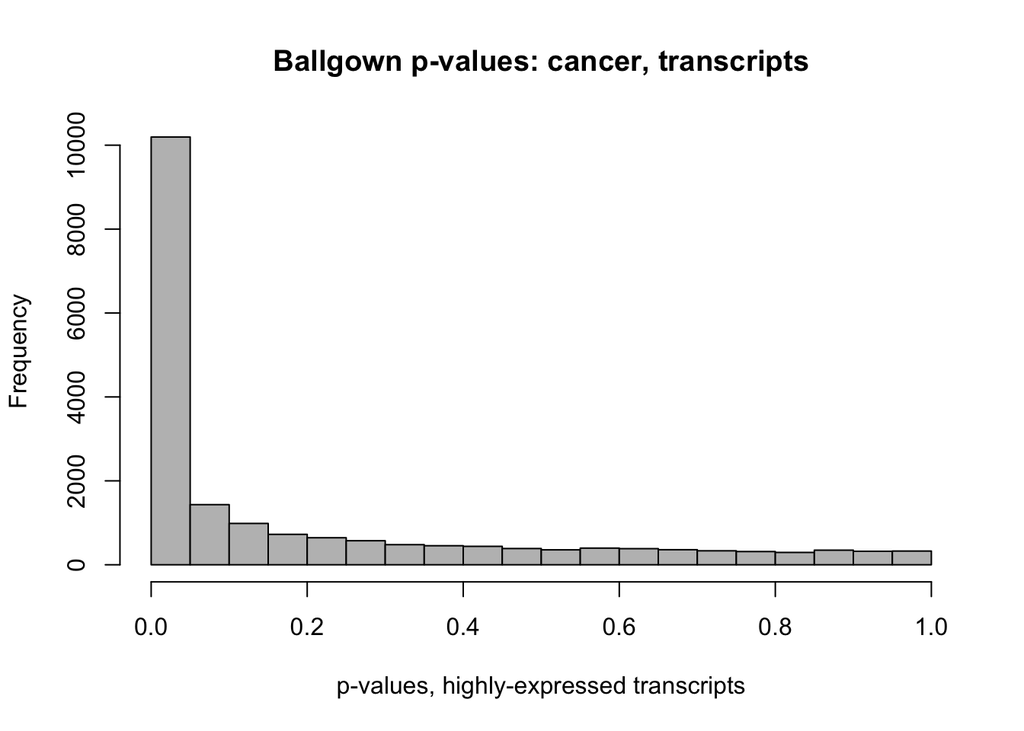

```r
hist(bgresults$pval[bgresults$id %in% hiID], main='Ballgown p-values: cancer, transcripts', xlab='p-values, highly-expressed transcripts', col='gray')
```

Ballgown still appears to be calling more transcripts differentially expressed than Cuffdiff 2.2.1 (see the y-axis scales).

We will also compare Ballgown and Cuffdiff to EBSeq, another method for transcript-level differential expression analysis.

```r
Data = acast(rdata, formula=tracking_id~replicate+condition, value.var='raw_frags')
Conditions = rep(c('normal', 'tumor'), 12)
IsoformNames = rownames(Data)
iso_gene_relationship = read.table('cancer/isoform_exp.diff',
    colClasses=c('character', 'character', rep('NULL', 12)), header=TRUE)
sum(IsoformNames != iso_gene_relationship$test_id) # expect 0
```

```
## [1] 0
```

```r
IsosGeneNames = iso_gene_relationship$gene_id
IsoSizes = MedianNorm(Data)
NgList = GetNg(IsoformNames, IsosGeneNames)
IsoNgTrun = NgList$IsoformNgTrun

system.time(IsoEBOut <- EBTest(Data=Data, NgVector=IsoNgTrun,
    Conditions=as.factor(Conditions), sizeFactors=IsoSizes, maxround=10))
```

```
## Removing transcripts with 75 th quantile < = 10
## 27058 transcripts will be tested
```

```
## iteration 1 done
##
## time 8098.39
##
## iteration 2 done
##
## time 110.91
##
## iteration 3 done
##
## time 61.38
##
## iteration 4 done
##
## time 13399.31
##
## iteration 5 done
##
## time 58
##
## iteration 6 done
##
## time 59.16
##
## iteration 7 done
##
## time 59.05
##
## iteration 8 done
##
## time 55.25
##
## iteration 9 done
##
## time 53.4
##
## iteration 10 done
##
## time 54.89
```

```
##      user    system   elapsed
##   812.993   130.654 22016.389
```

Check convergence:

```r
IsoEBOut$Alpha
```

```
##             [,1]
## iter1  0.7339298
## iter2  0.7407920
## iter3  0.7424806
## iter4  0.7453080
## iter5  0.7467419
## iter6  0.7458152
## iter7  0.7456511
## iter8  0.7456511
## iter9  0.7456511
## iter10 0.7456511
```

```r
IsoEBOut$Beta
```

```
##             Ng1      Ng2      Ng3
## iter1  7.141613 8.937612 9.195603
## iter2  7.543387 9.798918 9.381928
## iter3  7.588502 9.915011 9.379198
## iter4  7.632276 9.925067 9.449404
## iter5  7.651755 9.952981 9.465072
## iter6  7.643028 9.936936 9.452125
## iter7  7.641525 9.946158 9.463239
## iter8  7.641525 9.946158 9.463239
## iter9  7.641525 9.946158 9.463239
## iter10 7.641525 9.946158 9.463239
```

```r
IsoEBOut$P
```

```
##             [,1]
## iter1  0.4502060
## iter2  0.5124133
## iter3  0.5363185
## iter4  0.5459579
## iter5  0.5491767
## iter6  0.5509358
## iter7  0.5516766
## iter8  0.5516766
## iter9  0.5516766
## iter10 0.5516766
```

Convergence looks fine (all parameters are showing differences of < 1e-3 between the last few iterations).

The relevant differential expression output from EBSeq is the posterior probability of differential expression. To be consistent with a q-value cutoff of 0.05, we will say that EBSeq called a transcript differentially expressed if its posterior probability of differential expression is at least 95%:

```r
prob_de = IsoEBOut$PPDE
sum(prob_de > 0.95)
```

```
## [1] 8736
```

```r
sum(prob_de > 0.95) / length(prob_de)
```

```
## [1] 0.322862
```

So EBSeq calls 32.2862 percent of the transcripts it tested differentially expressed. We compare this to Ballgown/Cuffdiff results:

```r
statq_new = p.adjust(bgresults$pval[bgresults$id %in% hiID], 'fdr')
length(which(statq_new < 0.05))
```

```
## [1] 8875
```

```r
sum(statq_new < 0.05) / length(statq_new)
```

```
## [1] 0.4494126
```

```r
cuffq_new = p.adjust(hitranscripts$p_value[hitranscripts$status == "OK"], 'fdr')
length(which(cuffq_new < 0.05))
```

```
## [1] 4608
```

```r
sum(cuffq_new < 0.05) / length(cuffq_new)
```

```
## [1] 0.2342177
```

So, in the cancer dataset, Ballgown calls 44.9412599 percent of its tested (highly-expressed) transcripts differentially expressed, and Cuffdiff calls 23.4217749 percent of its tested, highly-expressed transcripts differentially expressed.

Here is Supplementary Figure 5a:

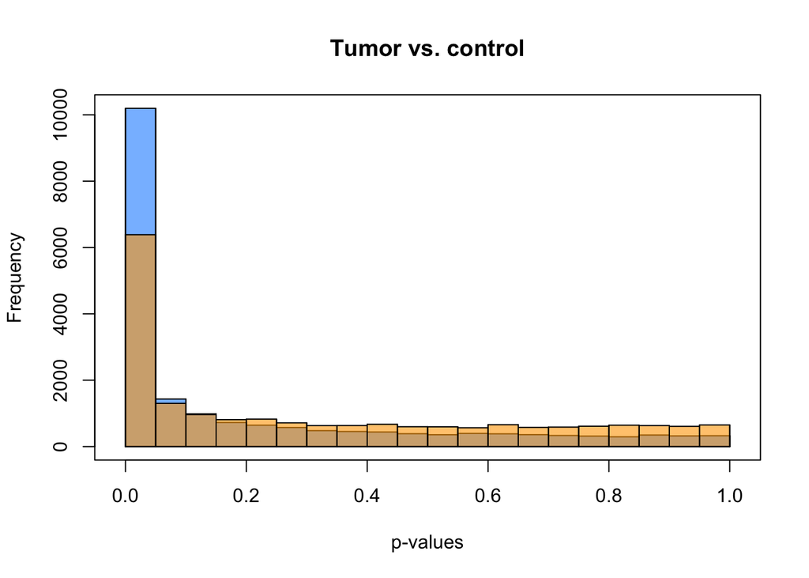

```r
bhist(bgresults$pval[bgresults$id %in% hiID], fill='dodgerblue', alpha=0.6,
    xlab="p-values", ylab='Frequency', main="Tumor vs. control")
bhist(hitranscripts$p_value[hitranscripts$status == "OK"], fill='orange', alpha=0.6,
    add=TRUE)
```

Again, Cuffdiff is looking much more reasonable than version 2.0.2. Ballgown is still calling more transcripts differentially expressed, though.

### dataset 2: cell types

The second study compares expression in two types of early-development human cells: embryonic stem cells (n=34) and pre-implantation blastomeres (n=78). Study information is [available here](http://www.ncbi.nlm.nih.gov/geo/query/acc.cgi?acc=GSE36552). (GEO/NCBI accession number GSE36552).

We have already run Cuffdiff 2.2.1 on this dataset (see other scripts in this folder). Here we read in and reshape the Cuffdiff output:

```r
transcripts = read.table('celltype/isoform_exp.diff', header=TRUE)
rdata = read.table('celltype/isoforms.read_group_tracking', header=TRUE)
fpkmtable = dcast(rdata, formula=tracking_id~replicate+condition, value.var='FPKM')
hiexpr = which(rowMeans(fpkmtable[,-1]) > 1)
length(hiexpr)
```

```
## [1] 16430
```

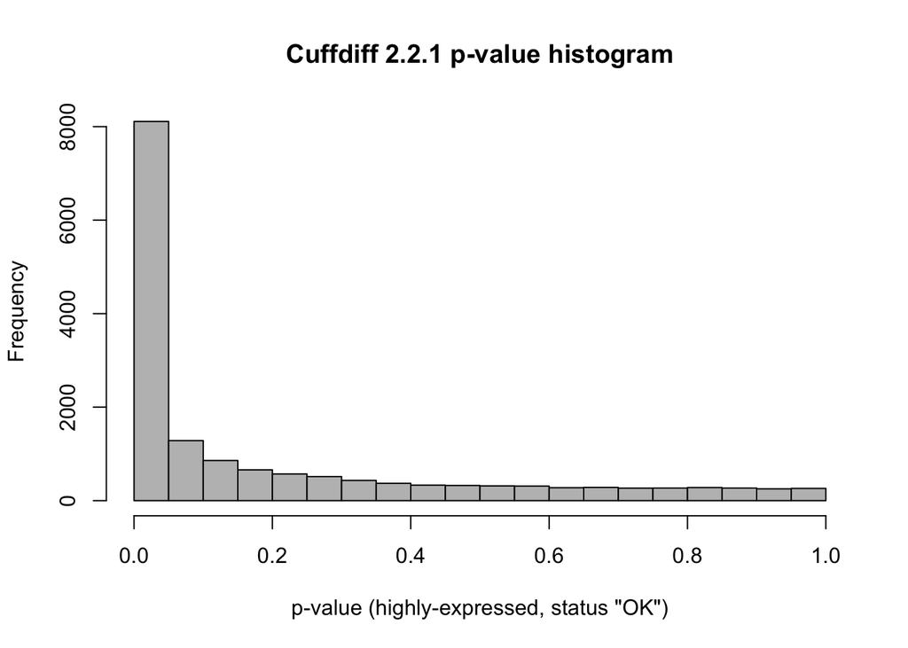

```r
hiID = fpkmtable$tracking_id[hiexpr]
hitranscripts = subset(transcripts, test_id %in% hiID)
hist(hitranscripts$p_value[hitranscripts$status == "OK"], xlab='p-value (highly-expressed, status "OK")', main='Cuffdiff 2.2.1 p-value histogram', col='gray')
```

This histogram looks *much* more reasonable than the one from the Cuffdiff version (2.0.2) used to create the dataset that’s actually available in InSilicoDb. Let’s also check the gene-level p-value histogram:

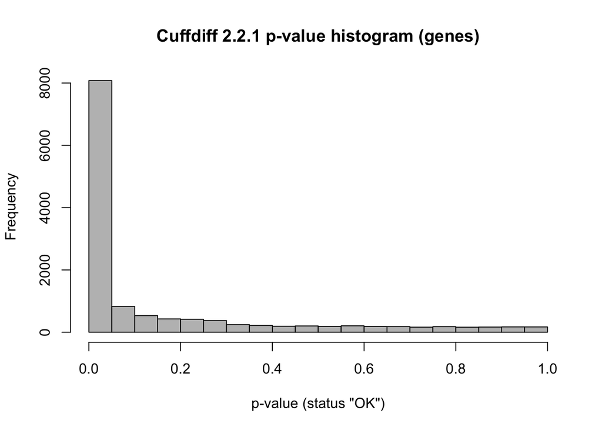

```r
genes = read.table('celltype/gene_exp.diff', header=TRUE)
hist(genes$p_value[genes$status=="OK"], xlab='p-value (status "OK")', main="Cuffdiff 2.2.1 p-value histogram (genes)", col='gray')
```

The gene-level histogram also looks reasonable for Cuffdiff 2.2.1.

The next block of code does Ballgown’s statistical analysis:

```r
bgtable = fpkmtable[,-1]
rownames(bgtable) = fpkmtable[,1]
system.time(bgresults <- stattest(gowntable=bgtable,
    pData=data.frame(group=as.numeric(grepl('embryonic', names(bgtable)))),
    feature='transcript', covariate='group'))
```

```
##    user  system elapsed
##   2.321   0.299   2.754
```

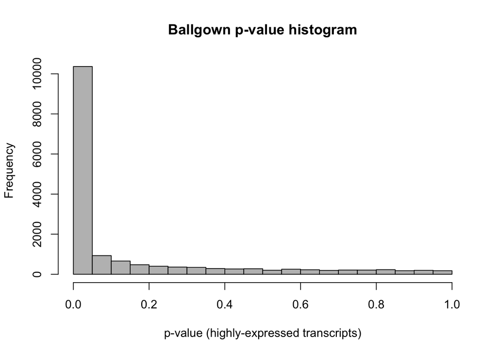

```r
hist(bgresults$pval[bgresults$id %in% hiID], main='Ballgown p-value histogram', xlab='p-value (highly-expressed transcripts)', col='gray')
```

```r
bgres_hi = bgresults[bgresults$id %in% hiID,]
bgres_hi$qval = p.adjust(bgres_hi$pval, 'fdr')
sum(bgres_hi$qval < 0.05)
```

```
## [1] 9701
```

We can show that the Ballgown results are basically equivalent to analyzing the “cell type” coefficient using limma:

```r
# calculate library size adjustment term manually:
lib_adj = apply(bgtable, 2, function(x){
    lognz = log2(x[x!=0] + 1)
    q3 = quantile(lognz, 0.75)
    sum(lognz[lognz<q3])
})
y = log2(bgtable+1)
group = as.numeric(grepl('embryonic', names(bgtable)))
x = model.matrix(~group + lib_adj)
fit = lmFit(y, x)
fit = eBayes(fit, trend=TRUE)
```

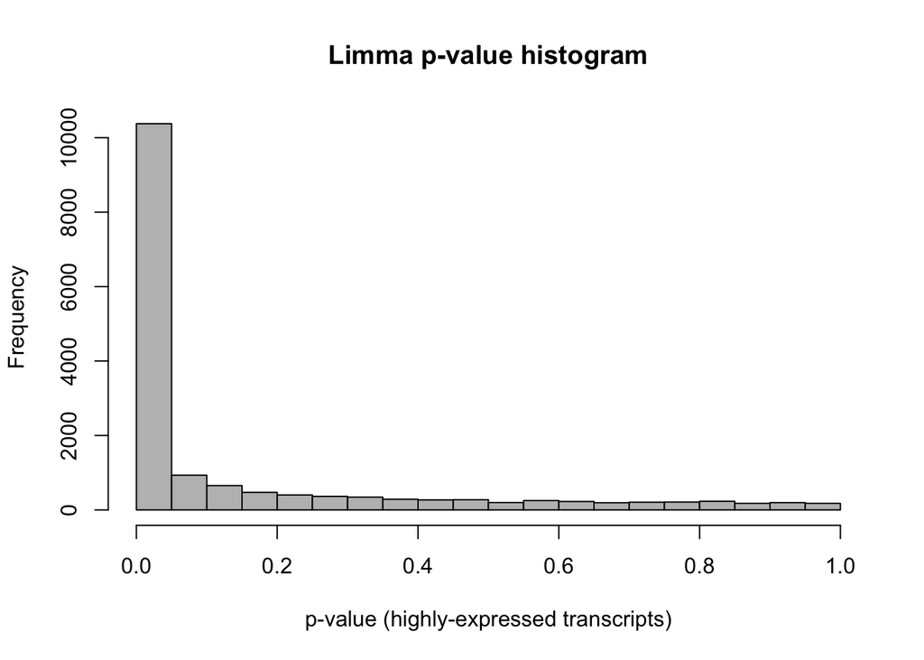

```r
limma_p = fit$p.value[,2][names(fit$p.value[,2]) %in% hiID]
hist(limma_p, xlab='p-value (highly-expressed transcripts)', main='Limma p-value histogram', col='gray')
```

The limma results are almost exactly the same as the ballgown results:

```r
# make sure everything is in the same order: expect 0
sum(names(limma_p) != bgres_hi$id)
```

```
## [1] 0
```

```r
sum(names(limma_p) != hitranscripts$test_id)
```

```
## [1] 0
```

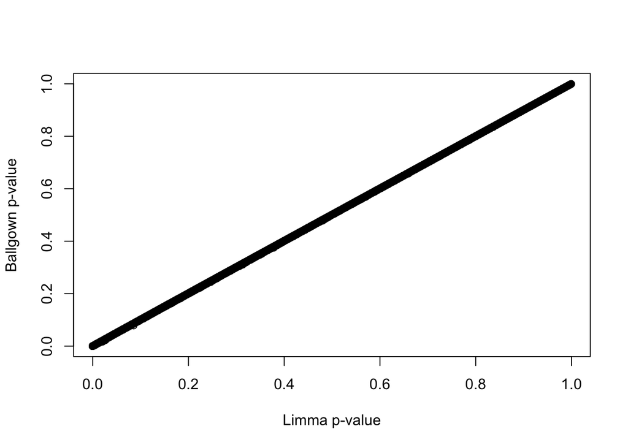

```r
plot(limma_p, bgres_hi$pval, xlab='Limma p-value', ylab='Ballgown p-value')
```

```r
cor(limma_p, bgres_hi$pval)
```

```
## [1] 0.9999982
```

```r
cor(limma_p, hitranscripts$p_value)
```

```
## [1] 0.5303104
```

```r
sum(limma_p == bgres_hi$pval) # not *exactly* equal
```

```
## [1] 0
```

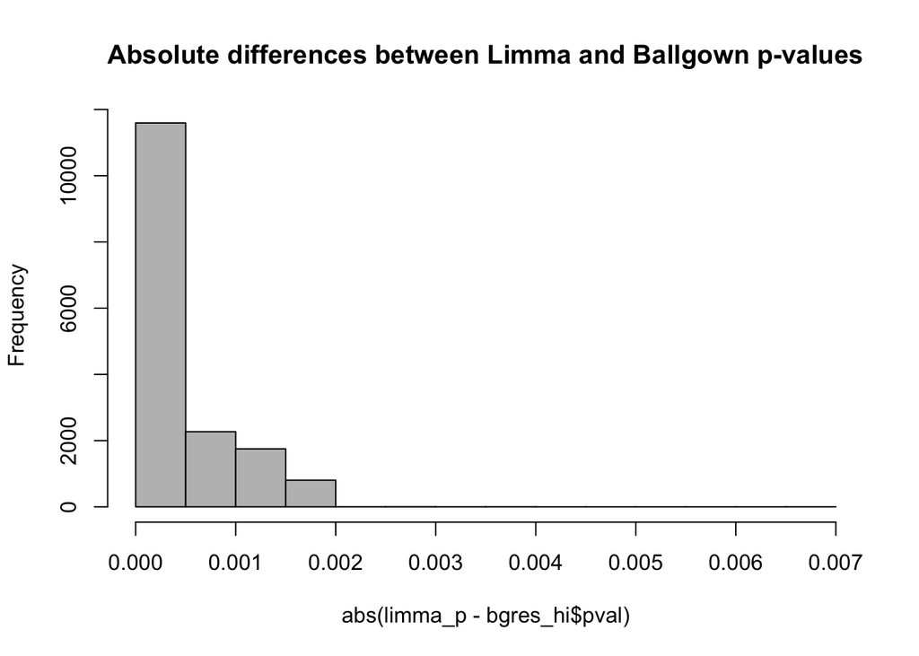

```r
hist(abs(limma_p - bgres_hi$pval), main='Absolute differences between Limma and Ballgown p-values', col='gray')
```

Here Supplementary Figure 5c:

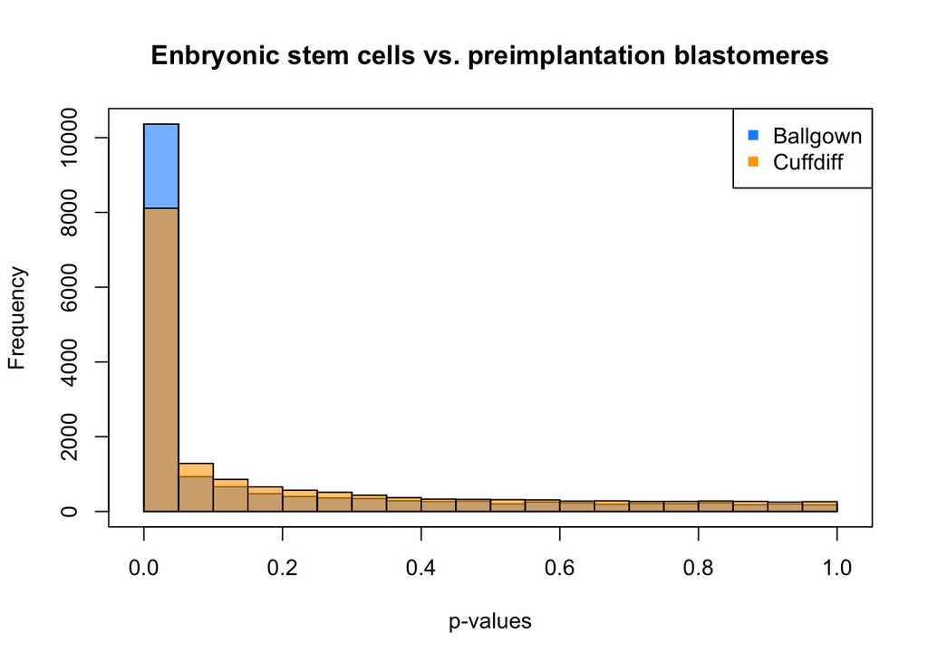

```r
bhist(bgresults$pval[bgresults$id %in% hiID], fill='dodgerblue',
    alpha=0.6, xlab="p-values", ylab='Frequency',
    main="Enbryonic stem cells vs. preimplantation blastomeres")
bhist(hitranscripts$p_value[hitranscripts$status == "OK"],
    fill='orange', alpha=0.6, add=TRUE)
legend('topright', col=c('dodgerblue', 'orange'), pch=c(15,15), c('Ballgown', 'Cuffdiff'))
```

We can also run EBSeq on this same dataset, to get a feel for how other differential expression methods are performing here:

```r
Data = acast(rdata, formula=tracking_id~replicate+condition, value.var='raw_frags')
Conditions = ballgown:::ss(colnames(Data), pattern='_', slot=2)
IsoformNames = rownames(Data)
iso_gene_relationship = read.table('celltype/isoform_exp.diff',
    colClasses=c('character', 'character', rep('NULL', 12)), header=TRUE)
sum(IsoformNames != iso_gene_relationship$test_id) # expect 0
```

```
## [1] 0
```

```r
IsosGeneNames = iso_gene_relationship$gene_id
IsoSizes = MedianNorm(Data)
NgList = GetNg(IsoformNames, IsosGeneNames)
IsoNgTrun = NgList$IsoformNgTrun

system.time(IsoEBOut <- EBTest(Data=Data, NgVector=IsoNgTrun,
    Conditions=as.factor(Conditions), sizeFactors=IsoSizes, maxround=20))
```

```
## Removing transcripts with 75 th quantile < = 10
## 15462 transcripts will be tested
```

```
## iteration 1 done
##
## time 460.69
##
## iteration 2 done
##
## time 251.16
##
## iteration 3 done
##
## time 106.36
##
## iteration 4 done
##
## time 90.08
##
## iteration 5 done
##
## time 111.86
##
## iteration 6 done
##
## time 92.42
##
## iteration 7 done
##
## time 86.84
##
## iteration 8 done
##
## time 88.38
##
## iteration 9 done
##
## time 93.11
##
## iteration 10 done
##
## time 84.34
##
```

[output cut: 24 more lines]

```
## iteration 17 done
##
## time 82.81
##
## iteration 18 done
##
## time 80.79
##
## iteration 19 done
##
## time 80.9
##
## iteration 20 done
##
## time 80.49
```

```
##      user    system   elapsed
##  1965.081   352.542 37536.340
```

Check convergence of the EBSeq method:

```r
IsoEBOut$Alpha
```

```
##             [,1]
## iter1  0.4324461
## iter2  0.4411575
## iter3  0.4438514
## iter4  0.4467913
## iter5  0.4481814
## iter6  0.4490512
## iter7  0.4476053
## iter8  0.4479136
## iter9  0.4481659
## iter10 0.4481659
## iter11 0.4481659
## iter12 0.4481659
## iter13 0.4481659
## iter14 0.4481659
## iter15 0.4481659
## iter16 0.4481659
## iter17 0.4481659
## iter18 0.4481659
## iter19 0.4481659
## iter20 0.4481659
```

```r
IsoEBOut$Beta
```

```
##             Ng1      Ng2      Ng3
## iter1  10.32390 15.65129 10.67099
## iter2  11.38244 13.06317 12.91556
## iter3  11.60044 13.42303 13.38059
## iter4  11.85870 13.51587 13.48804
## iter5  11.87135 13.62479 13.64263
## iter6  11.92345 13.66675 13.61625
## iter7  11.88634 13.64102 13.55806
## iter8  11.85640 13.67390 13.61654
## iter9  11.91010 13.69983 13.62694
## iter10 11.91010 13.69983 13.62694
## iter11 11.91010 13.69983 13.62694
## iter12 11.91010 13.69983 13.62694
## iter13 11.91010 13.69983 13.62694
## iter14 11.91010 13.69983 13.62694
## iter15 11.91010 13.69983 13.62694
## iter16 11.91010 13.69983 13.62694
## iter17 11.91010 13.69983 13.62694
## iter18 11.91010 13.69983 13.62694
## iter19 11.91010 13.69983 13.62694
## iter20 11.91010 13.69983 13.62694
```

```r
IsoEBOut$P
```

```
##             [,1]
## iter1  0.6719648
## iter2  0.7802795
## iter3  0.8101720
## iter4  0.8213874
## iter5  0.8256078
## iter6  0.8273323
## iter7  0.8277535
## iter8  0.8279056
## iter9  0.8286870
## iter10 0.8286870
## iter11 0.8286870
## iter12 0.8286870
## iter13 0.8286870
## iter14 0.8286870
## iter15 0.8286870
## iter16 0.8286870
## iter17 0.8286870
## iter18 0.8286870
## iter19 0.8286870
## iter20 0.8286870
```

The relevant differential expression output from EBSeq is the posterior probability of differential expression. To be consistent with a q-value cutoff of 0.05, we will say that EBSeq called a transcript differentially expressed if its posterior probability of differential expression is at least 95%:

```r
prob_de = IsoEBOut$PPDE
sum(prob_de > 0.95)
```

```
## [1] 10307
```

```r
sum(prob_de > 0.95) / length(prob_de)
```

```
## [1] 0.666602
```

So EBSeq calls 66.6601992 percent of the transcripts it tested differentially expressed. We compare this to Ballgown/Cuffdiff results:

```r
# readjust q-values using high transcripts only
statq_new = p.adjust(bgresults$pval[bgresults$id %in% hiID], 'fdr')
length(which(statq_new < 0.05)) #9701
```

```
## [1] 9701
```

```r
sum(statq_new < 0.05) / length(statq_new)
```

```
## [1] 0.5904443
```

```r
cuffq_new = p.adjust(hitranscripts$p_value[hitranscripts$status == "OK"], 'fdr')
length(which(cuffq_new < 0.05)) #6816
```

```
## [1] 6816
```

```r
sum(cuffq_new < 0.05) / length(cuffq_new)
```

```
## [1] 0.4196786
```

So Ballgown calls 59.0444309 percent of its tested (highly-expressed) transcripts differentially expressed, and Cuffdiff calls 41.9678591 percent of its tested, highly-expressed transcripts differentially expressed.